# Homework3

Yongye Tan

10/22/2022

```r
rosca <- read.csv("rosca.csv")
```

```r
rosca$treatment <- NA
rosca$treatment[rosca$encouragement == 1] <- "control"
rosca$treatment[rosca$safe_box == 1] <- "safebox"
rosca$treatment[rosca$locked_box == 1] <- "lockbox"
rosca$treatment <- as.factor(rosca$treatment)
rosca <-  rosca[rosca$has_followup2 == 1, ]
rosca$bg_female <-  factor(rosca$bg_female )
rosca$bg_married <-  factor(rosca$bg_married)
```

# 1

[figure not shown]

```r
ggplot(data = rosca) +
  geom_bar(mapping = aes(treatment, fill = bg_female),
           position = "dodge") +
  theme(axis.title.x = element_blank()) +
  theme(axis.title.y = element_blank()) +
  # add a title
  labs(
    title = "Distribution of marital status"
  ) +
  # center the title and bold it
  theme(plot.title = element_text(hjust = 0.5, face = "bold")) +
  # change the legend label title and name
  scale_fill_discrete(name = "marital status",
                      labels = c("unmarried", "married"))
```

### b.

The barplots do not contain the exact numbers or proportions so we can add them to make the figure more informative. Make the following plot. Use geom_text to add the percentage for each bar (You don’t need to be perfect for the position of the annotation). The following codes calculate the counts and proportions of unmarried people under control, married people under control, unmarried people under lockbox, married people under lockbox, unmarried people under safebox, and married people under safebox. You need to change the proportions to the percentages. (You can use other methods for this. Check function percent() in scales package )

```r
y <- as.numeric(t(table(rosca$treatment,rosca$bg_married)))
prop <- table(rosca$treatment,rosca$bg_married)/length(rosca$treatment)
prop <- as.numeric(t(prop)) * 100
prop <- round(prop,  digits = 2)
```

[figure not shown]

```r
text <- data.frame(
  # set the text location
  x_pos = c(0.8,1.2,1.8,2.2,2.8,3.2),
  y_pos = c(32, 78, 53, 140, 25, 88),
  label = str_c(prop, "%")
)


ggplot(data = rosca) +
  geom_bar(mapping = aes(treatment, fill = bg_female),
           position = "dodge") +
  theme(axis.title.x = element_blank()) +
  theme(axis.title.y = element_blank()) +
  # add a title
  labs(
    title = "Distribution of marital status"
  ) +
  # center the title and bold it
  theme(plot.title = element_text(hjust = 0.5, face = "bold")) +
  # change the legend label title and name
  scale_fill_discrete(name = "marital status",
                      labels = c("unmarried", "married")) +
  geom_text(data = text,
            mapping = aes(x = x_pos,
            y = y_pos,
            label = label))
```

#2

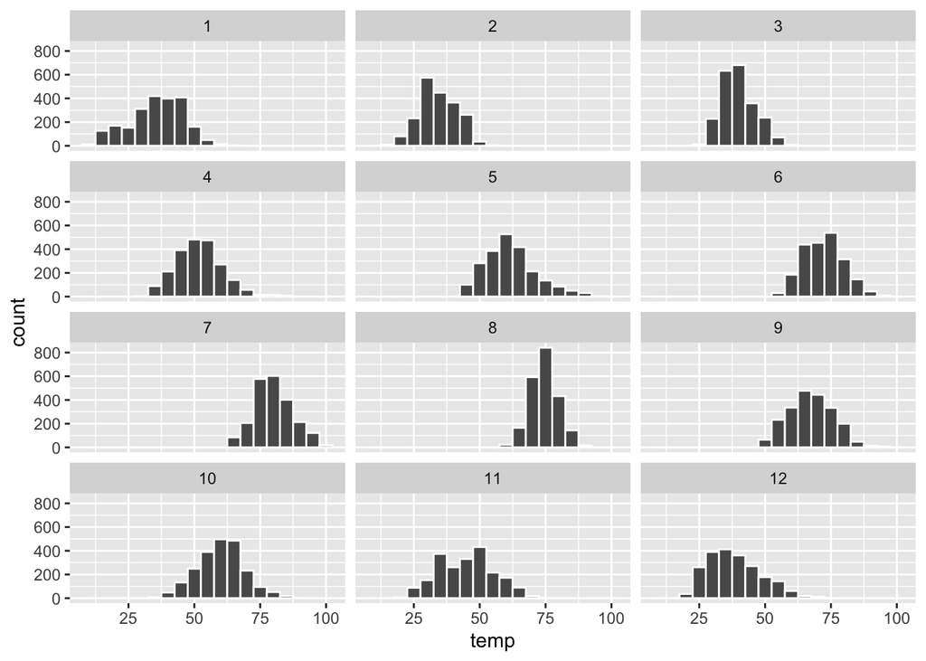

```r
# filter out the temp that is na
weather <- weather %>% filter(!is.na(temp))
temp.facet <- ggplot(data = weather)+
  geom_histogram(mapping = aes(x = temp),color= "white",binwidth = 5)+
  # total 4 rows
  facet_wrap(~month,nrow=4)
temp.facet
```

1. Add appropriate title and labels of axes. Remove the y-axis ticks and tick labels (200,400…)

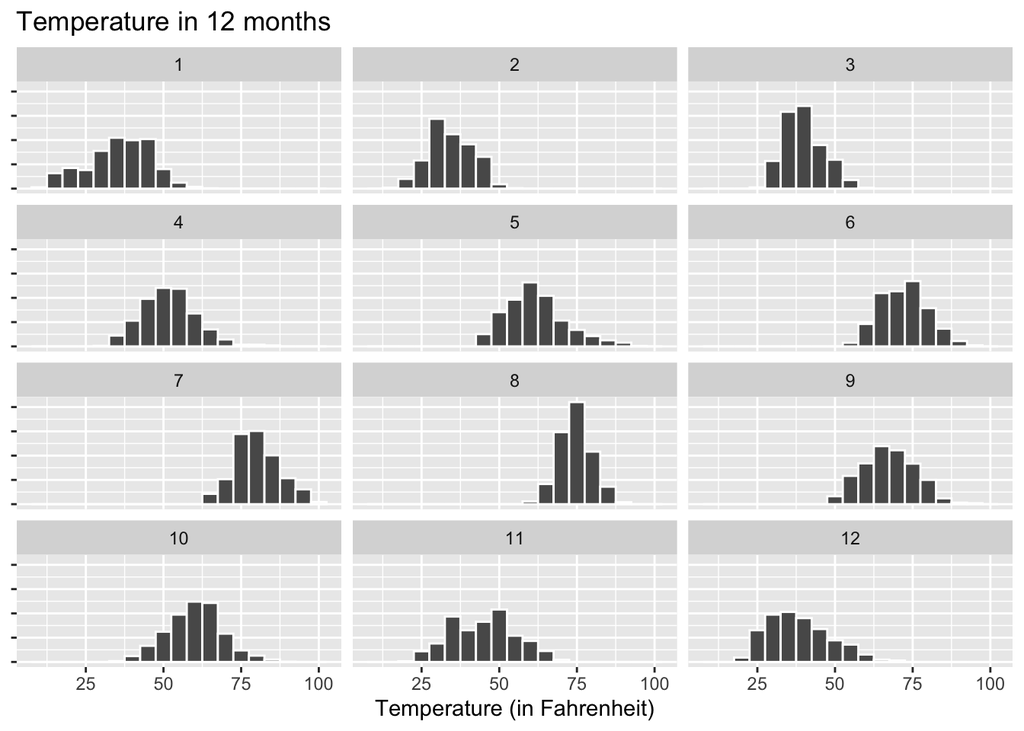

```r
temp.facet+ labs(
  title = "Temperature in 12 months",
  x = "Temperature (in Fahrenheit)",
  # remove the y-axis ticks
  y = NULL) +
  # remove the y tick labels
  scale_y_continuous(labels = NULL)
```

2. Change the facet labels from numeric month to month abbreviations, e.g., 1 to Jan.

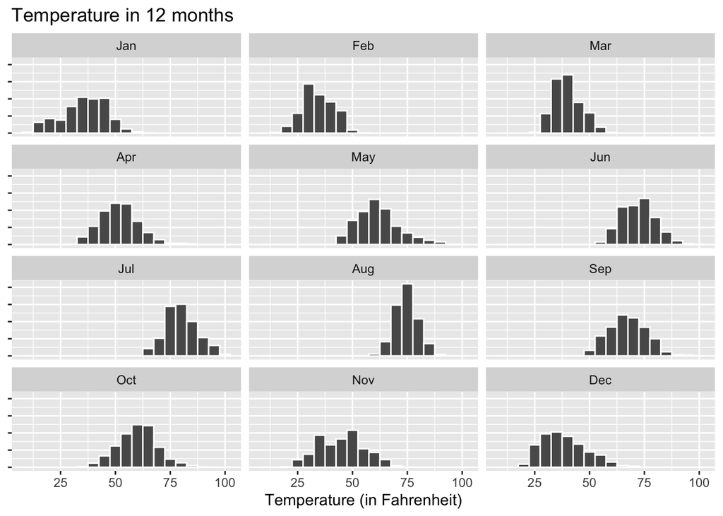

```r
# c(1,2,3,4,5,6,7,8,9,10,11,12)
month_label <- c (
                '1' = "Jan", '2' = "Feb",'3' = "Mar",'4' = "Apr",
                '5' = "May", '6' = "Jun",'7' = "Jul",'8' = "Aug",
                '9' = "Sep", '10' = "Oct",'11' = "Nov",'12' = "Dec")


month_label_plot <- ggplot(data = weather)+
  geom_histogram(mapping = aes(x = temp),color= "white",binwidth = 5) +
  # total 4 rows
  facet_wrap(~month,
             nrow=4,
             # match the label to the new label
             labeller = as_labeller(month_label))+
  labs(
      title = "Temperature in 12 months",
      x = "Temperature (in Fahrenheit)",
      y = NULL) +
      scale_y_continuous(labels = NULL)
month_label_plot
```

3. We can add the average termperature for each month to make the firgure more informative. Make the following plot. You can use round(tapply(weather$temp, factor(weather$month),mean)) to obtain the average temperature of each month.

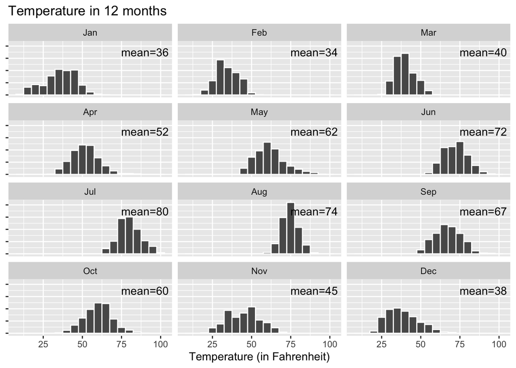

```r
month_label <- c (
                '1' = "Jan", '2' = "Feb",'3' = "Mar",'4' = "Apr",
                '5' = "May", '6' = "Jun",'7' = "Jul",'8' = "Aug",
                '9' = "Sep", '10' = "Oct",'11' = "Nov",'12' = "Dec")

temperature_mean <- round(tapply(weather$temp, factor(weather$month),mean))
temp_text <- data.frame(
  # this is important (help the label to find where it belongs 1 -> mean 34, 2 -> mean 32)
  month = c(1,2,3,4,5,6,7,8,9,10,11,12),
  # set the text location
  x = 90,
  y = 700,
  label = str_c("mean=",temperature_mean)
)

graph <- ggplot(data = weather, aes(x = temp )) +
  geom_histogram(color= "white",binwidth = 5) +
  # total 4 rows
  facet_wrap(~month,
             nrow=4,
             # match the label to the new label
             labeller = as_labeller(month_label)
             ) +
  labs(
      title = "Temperature in 12 months",
      x = "Temperature (in Fahrenheit)",
      y = NULL) +
      scale_y_continuous(labels = NULL)

graph +
     geom_text(
       data = temp_text,
       mapping = aes(x = x, y = y,
                     label = label)
     )
```

# 3

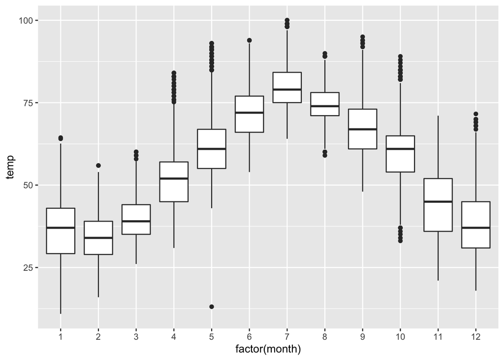

```r
ggplot(data = weather, mapping = aes(x= factor(month),y = temp)) +
  geom_boxplot()
```

1. Remove the x-axis label, and change the tick labels from numeric month to month abbreviation as in the following plot.

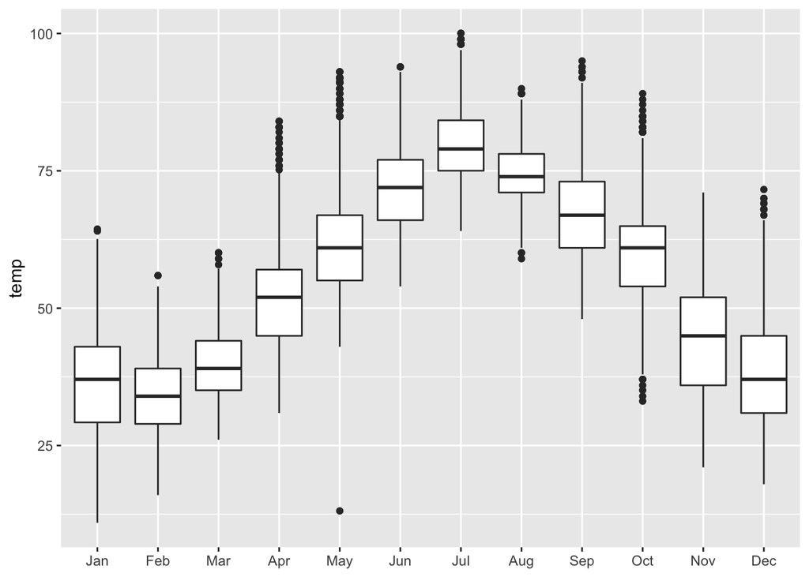

```r
month_label <- c (
                '1' = "Jan", '2' = "Feb",'3' = "Mar",'4' = "Apr",
                '5' = "May", '6' = "Jun",'7' = "Jul",'8' = "Aug",
                '9' = "Sep", '10' = "Oct",'11' = "Nov",'12' = "Dec")
ggplot(data = weather, mapping = aes(x= factor(month),y = temp)) +
  geom_boxplot() +
  labs(x= NULL) +
  # since these month are discrete
  scale_x_discrete(label = month_label)
```

2. Remove the y-axis label, and change the tick labels on the y-axis as in the following plot.

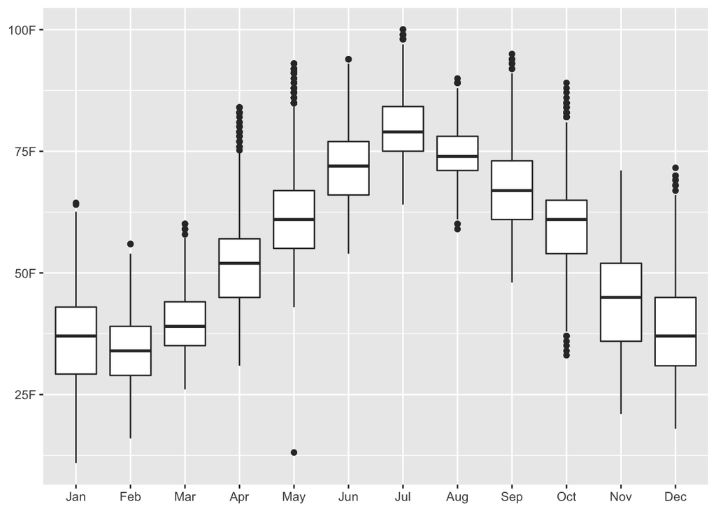

```r
month_label <- c (
                '1' = "Jan", '2' = "Feb",'3' = "Mar",'4' = "Apr",
                '5' = "May", '6' = "Jun",'7' = "Jul",'8' = "Aug",
                '9' = "Sep", '10' = "Oct",'11' = "Nov",'12' = "Dec")

ggplot(data = weather, mapping = aes(x= factor(month),y = temp)) +
  geom_boxplot() +
  labs(x= NULL,
       y = NULL) +
  # since these months are discrete
  scale_x_discrete(label = month_label) +
  # have to set the y axis mannually and and change the label mannually
  scale_y_continuous(breaks = seq(0, max(weather$temp, na.rm=TRUE), by = 25),
                     label = c("0" = "0F",
                               "25" = "25F",
                               "50" = "50F",
                               "75" = "75F",
                               "100" = "100F"))
```

3. (optional) We can make it better by adding the degree symbol. Make the following plot.

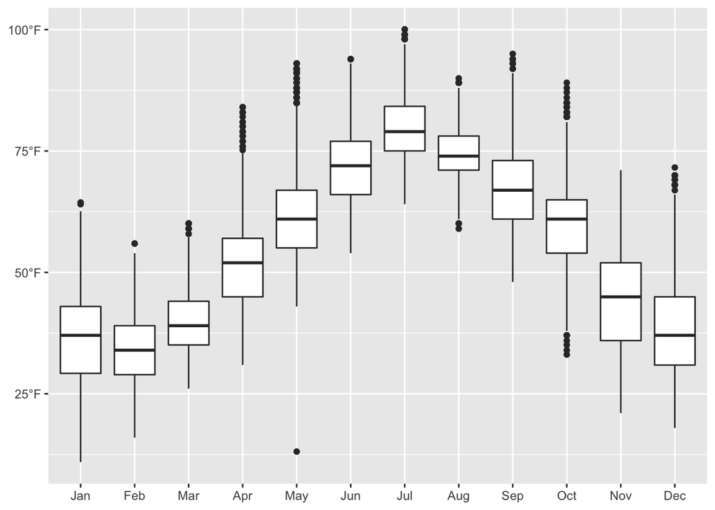

```r
month_label <- c (
                '1' = "Jan", '2' = "Feb",'3' = "Mar",'4' = "Apr",
                '5' = "May", '6' = "Jun",'7' = "Jul",'8' = "Aug",
                '9' = "Sep", '10' = "Oct",'11' = "Nov",'12' = "Dec")

ggplot(data = weather, mapping = aes(x= factor(month),y = temp)) +
  geom_boxplot() +
  labs(x= NULL,
       y = NULL) +
  # since these months are discrete
  scale_x_discrete(label = month_label) +
  # have to set the y axis mannually and and change the label mannually
  scale_y_continuous(breaks = seq(0, max(weather$temp, na.rm=TRUE), by = 25),
                     label = c("0" = "0°F",
                               "25" = "25°F",
                               "50" = "50°F",
                               "75" = "75°F",
                               "100" = "100°F"))
```